# Cross test using Operating Model based on Life History

LBSPR, length based assessment

L Kell

17 November, 2018

## Turbot

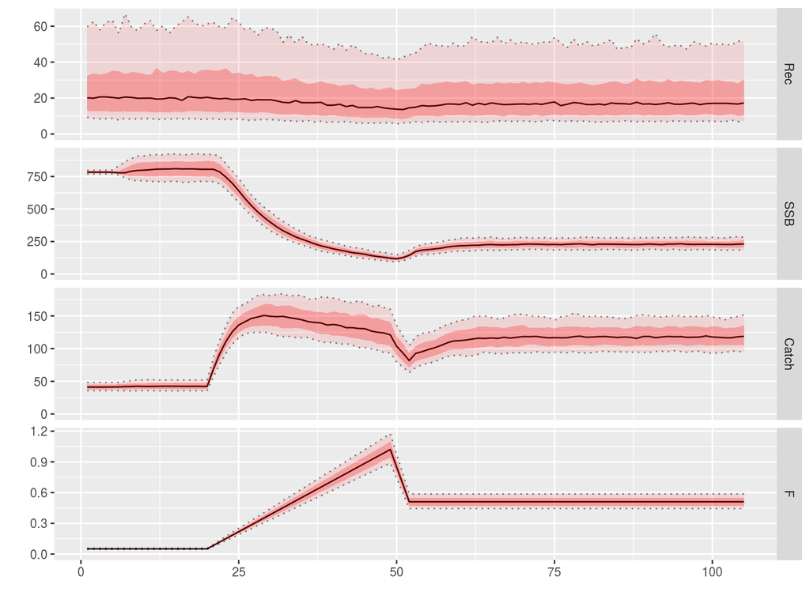

**Figure 1** Operating model for turbot.

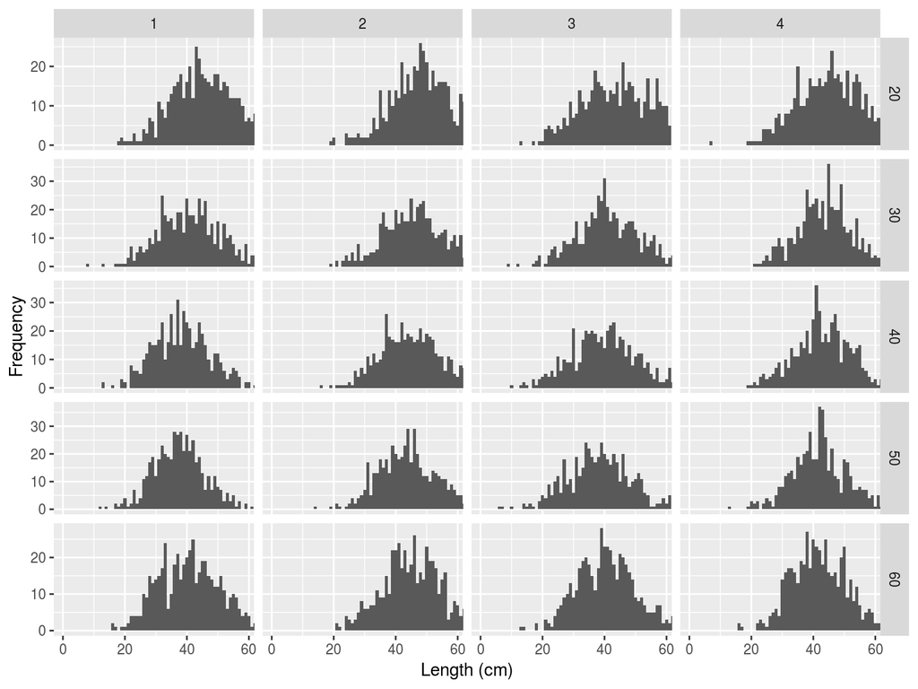

**Figure 2** Observation error model for turbot.

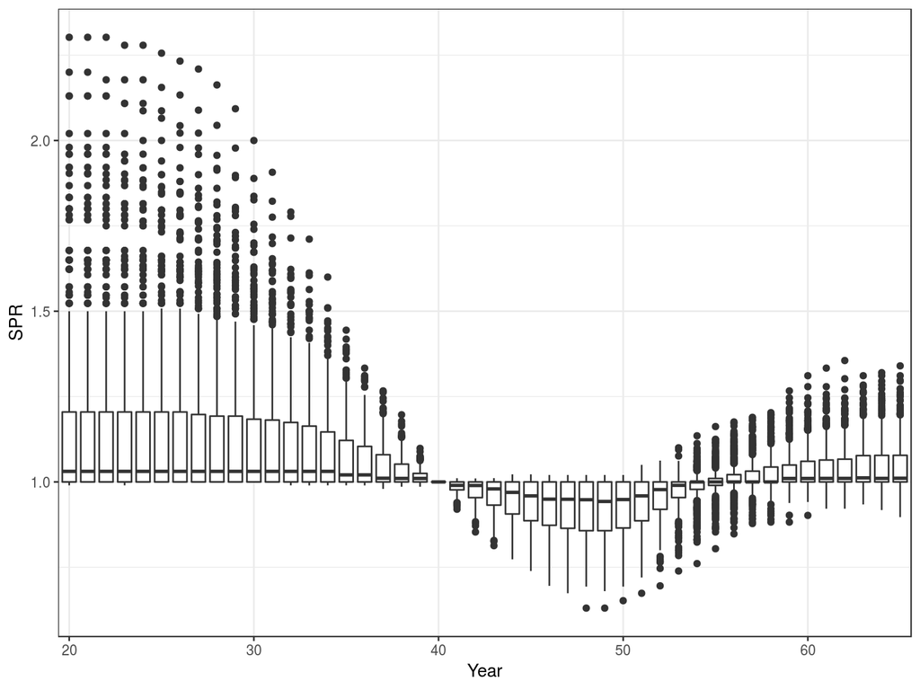

**Figure 3** Estimates of SPR for turbot.

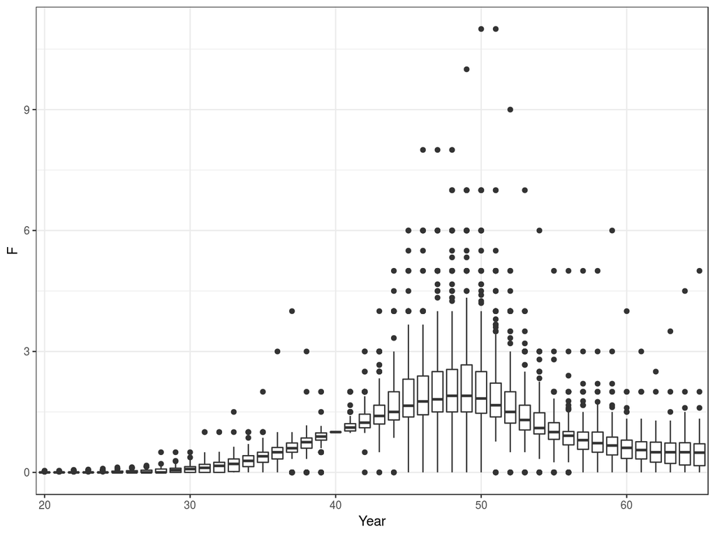

**Figure 4** Estimates of $F/M$ for turbot.

## Brill

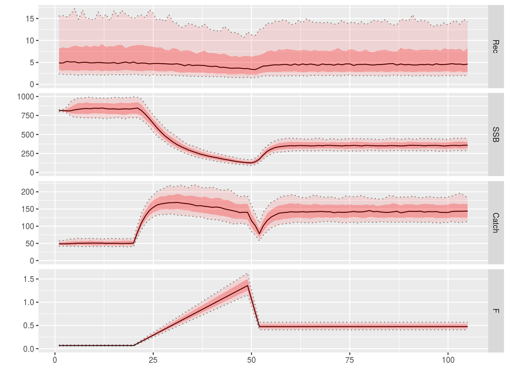

**Figure 5** Operating model for Brill.

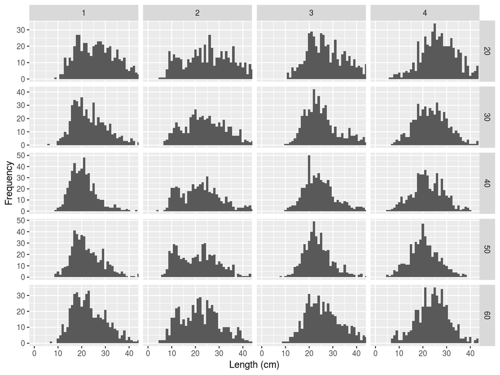

**Figure 6** Observation error model for Brill.

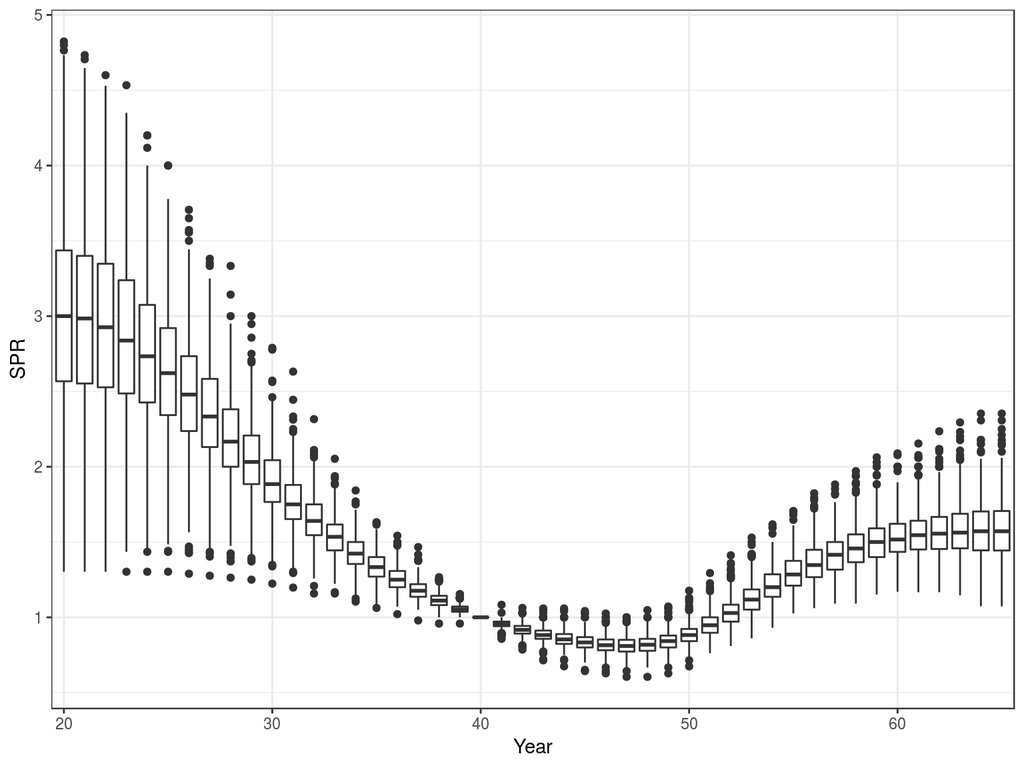

**Figure 7** Estimates of SPR for brill.

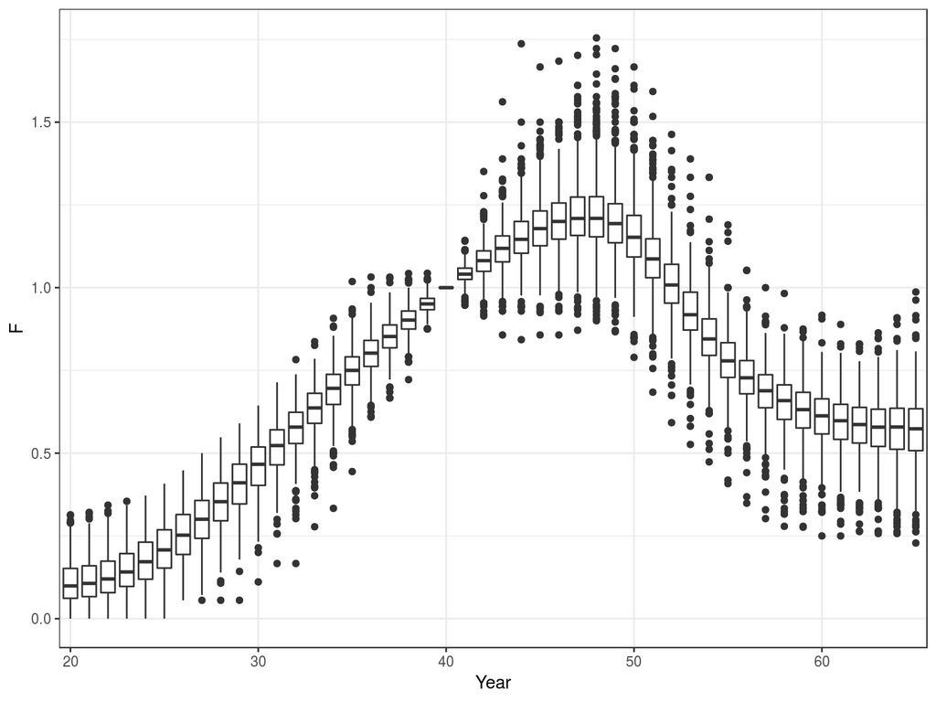

**Figure 8** Estimates of $F/M$ for brill.

## Ray

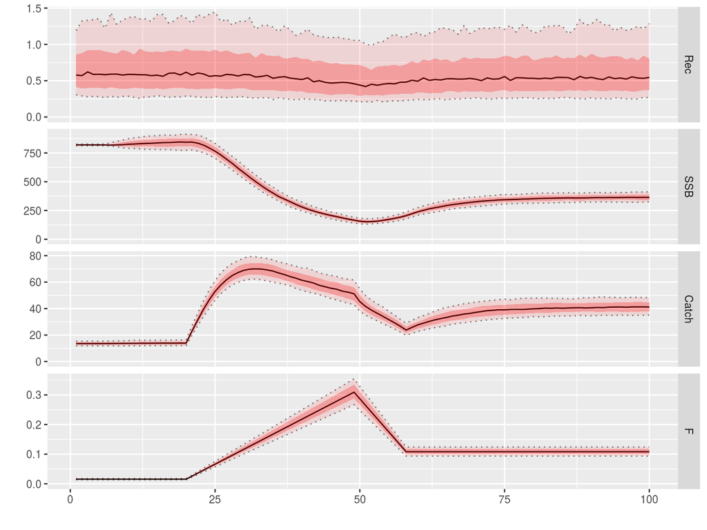

**Figure 9** Operating model for ray.

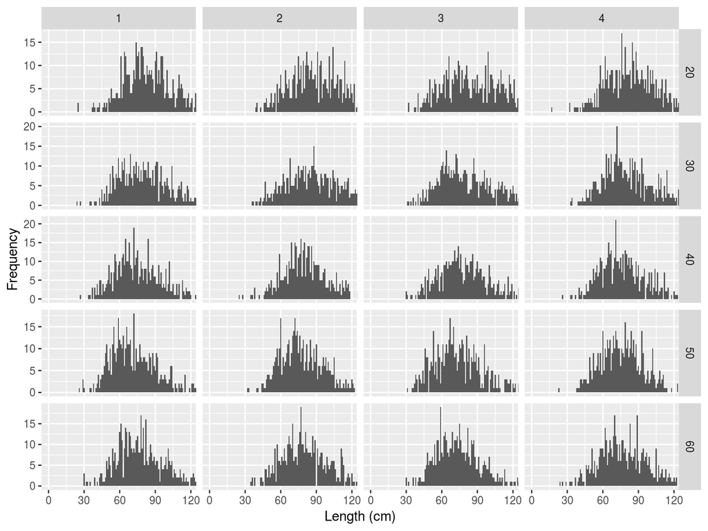

**Figure 10** Observation error model for ray.

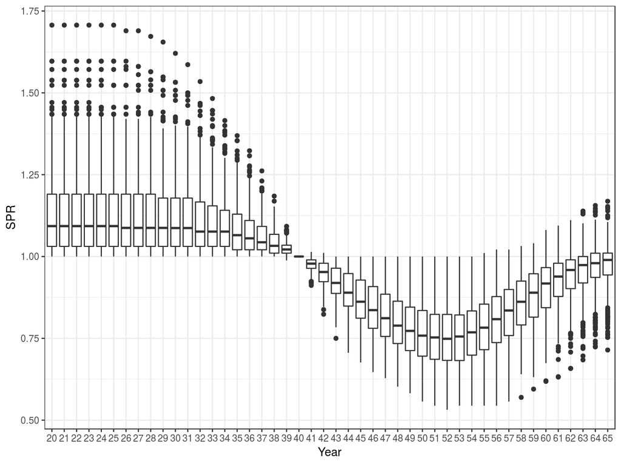

**Figure 11** Estimates of SPR for ray.

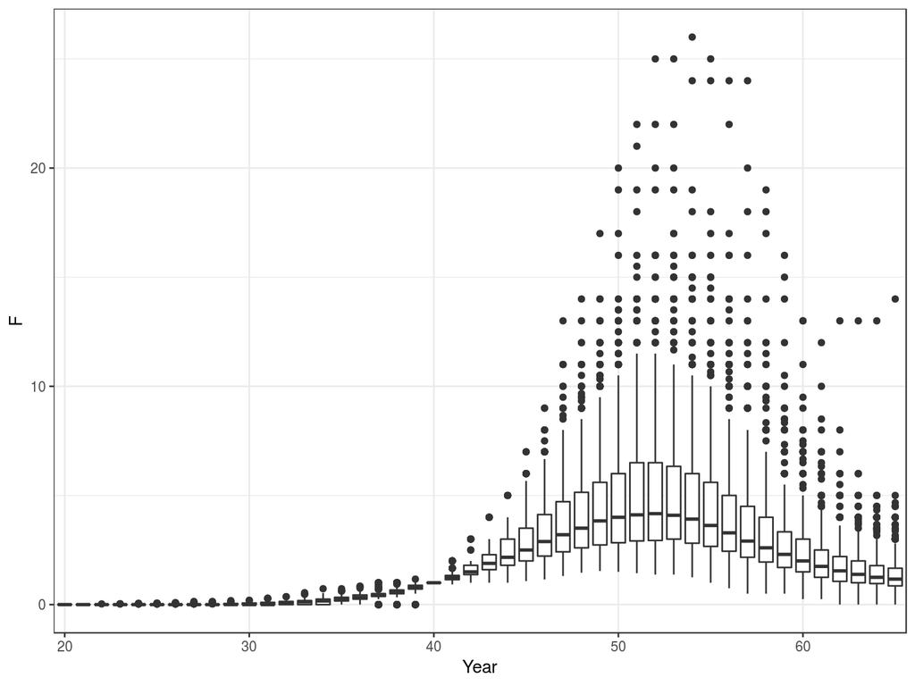

**Figure 12** Estimates of $F/M$ for ray.

## sprat

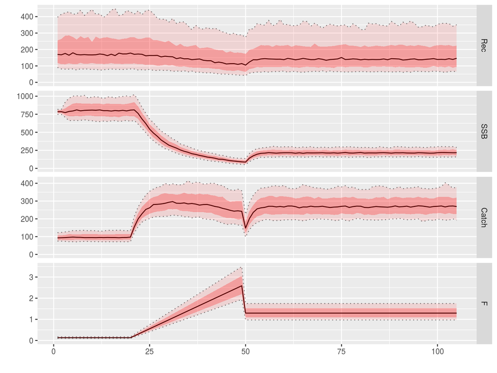

**Figure 13** Operating model for sprat.

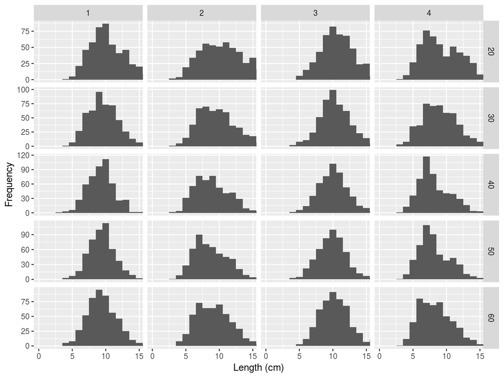

**Figure 14** Observation error model for sprat.

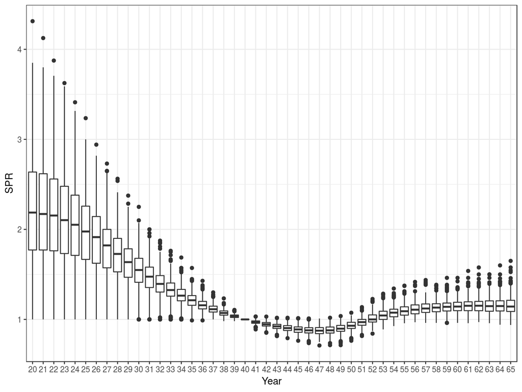

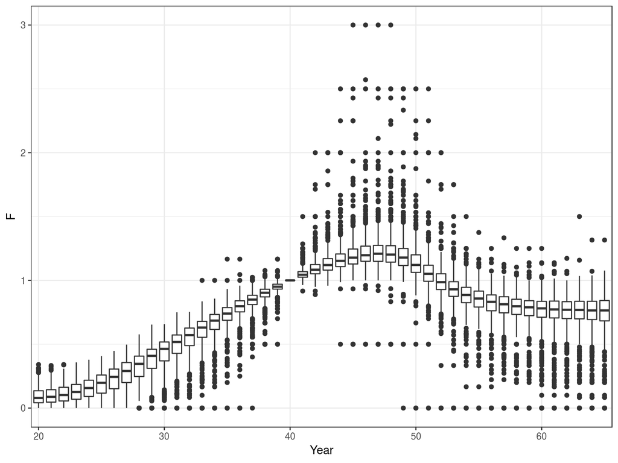

## pollack

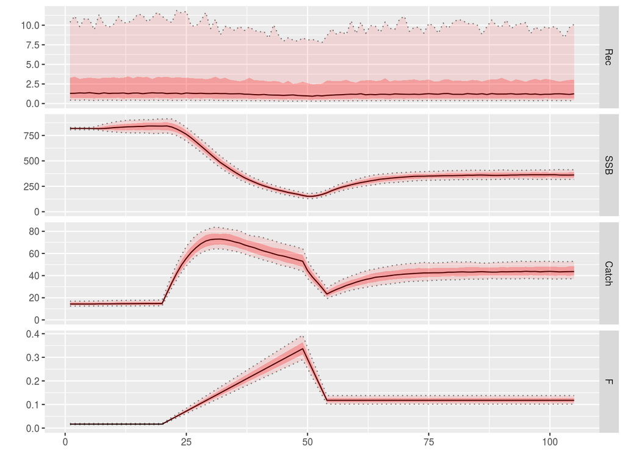

**Figure 17** Operating model for pollack.

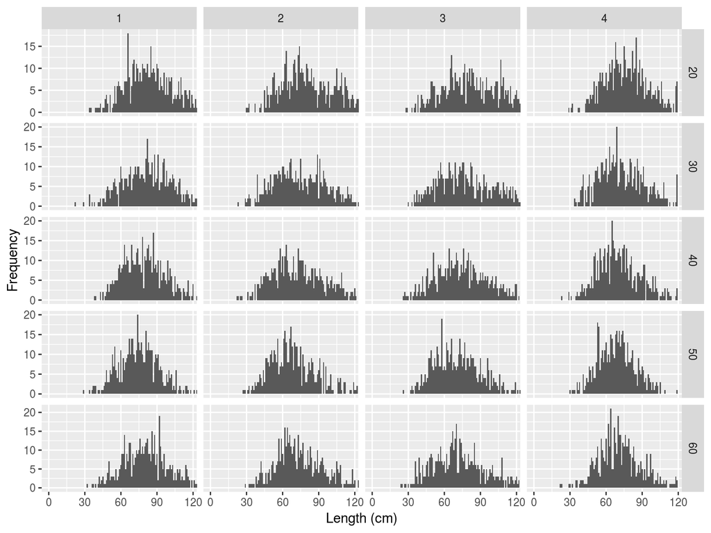

**Figure 18** Observation error model for pollack.

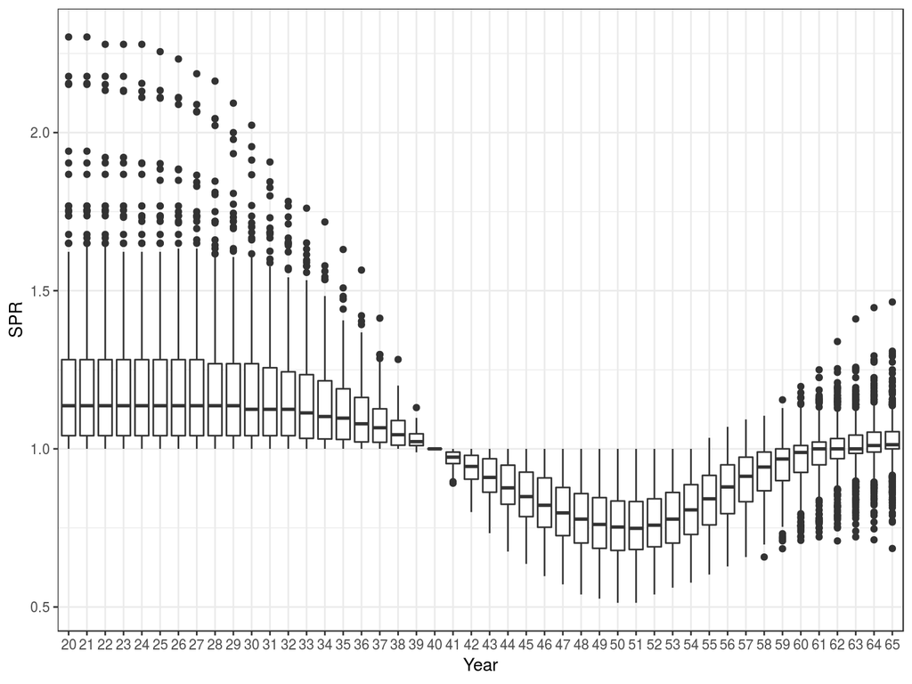

**Figure 19** Estimates of SPR for pollack.

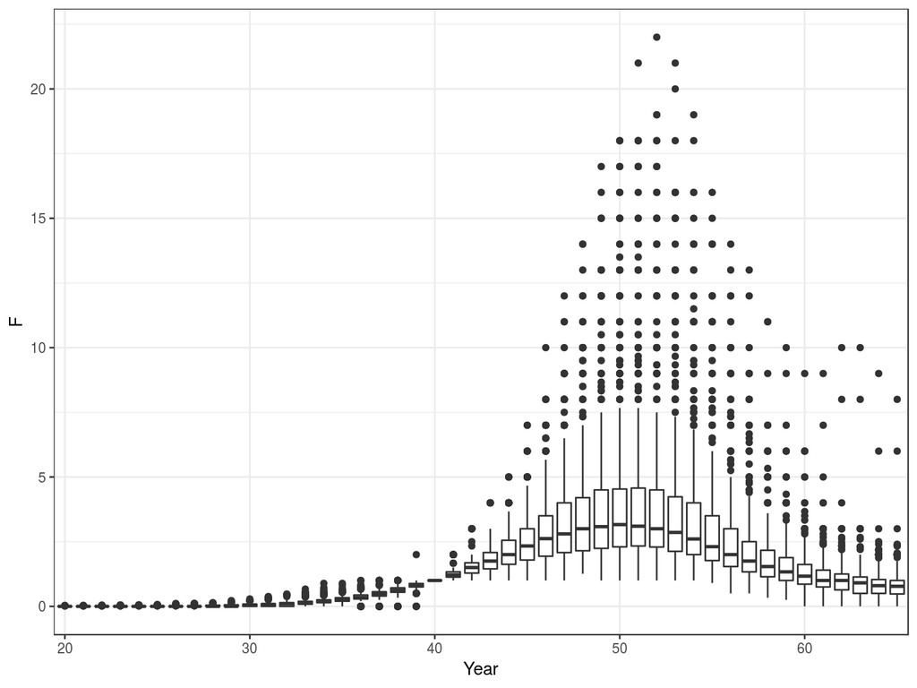

**Figure 20** Estimates of $F/M$ for pollack.

## razor

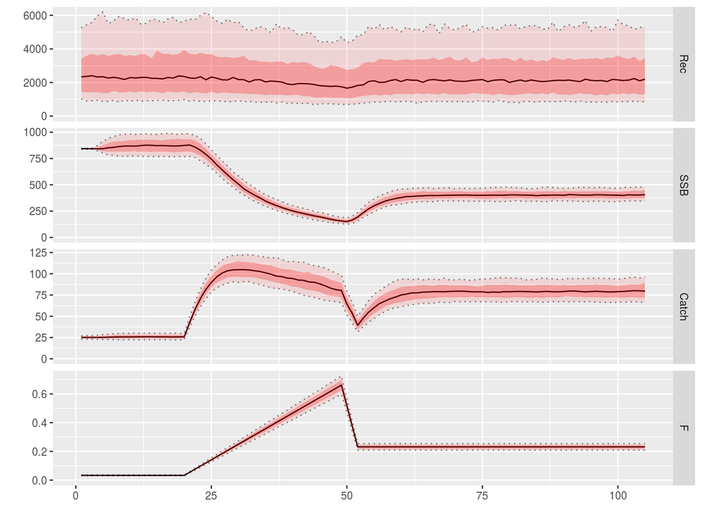

**Figure 21** Operating model for razor.

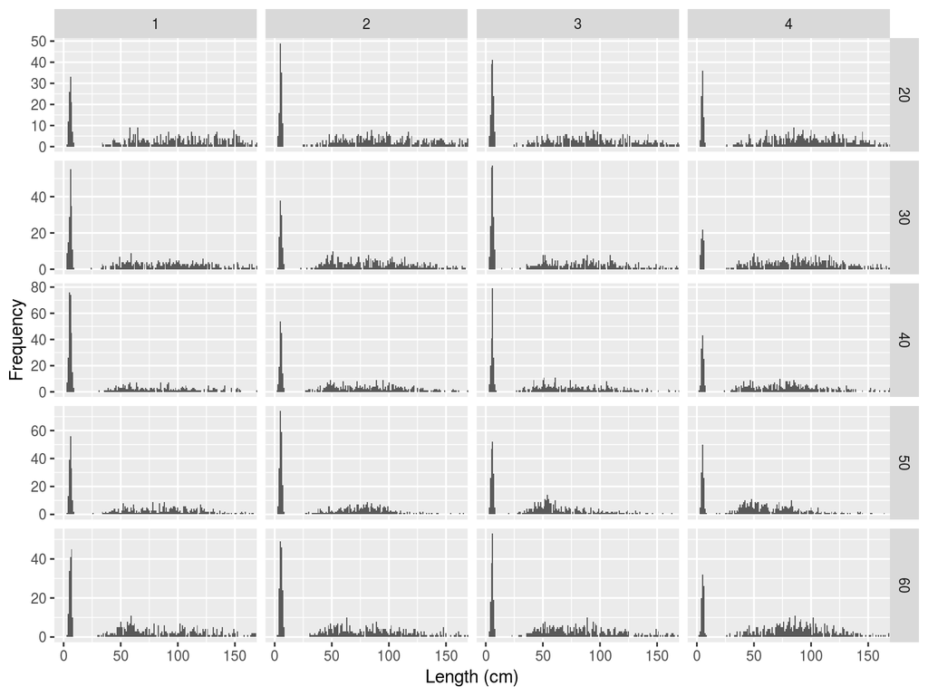

**Figure 22** Observation error model for razor.

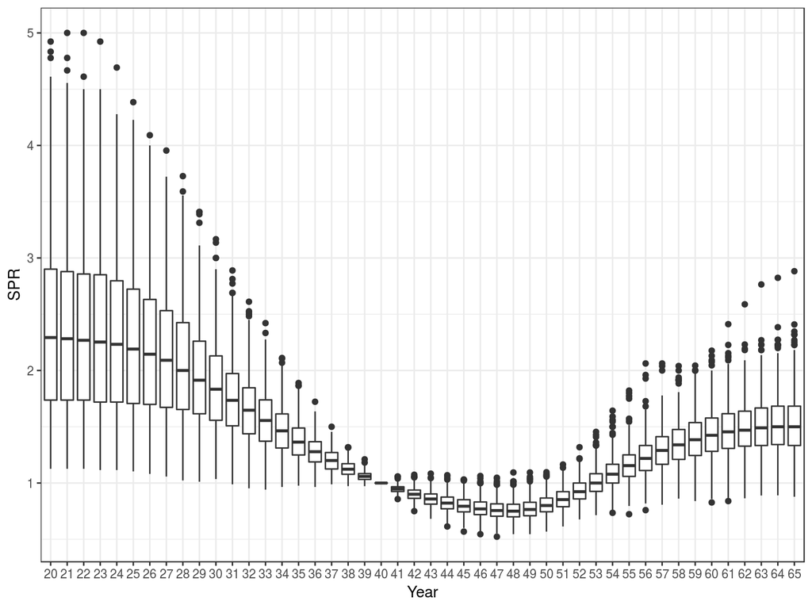

**Figure 23** Estimates of SPR for razors.

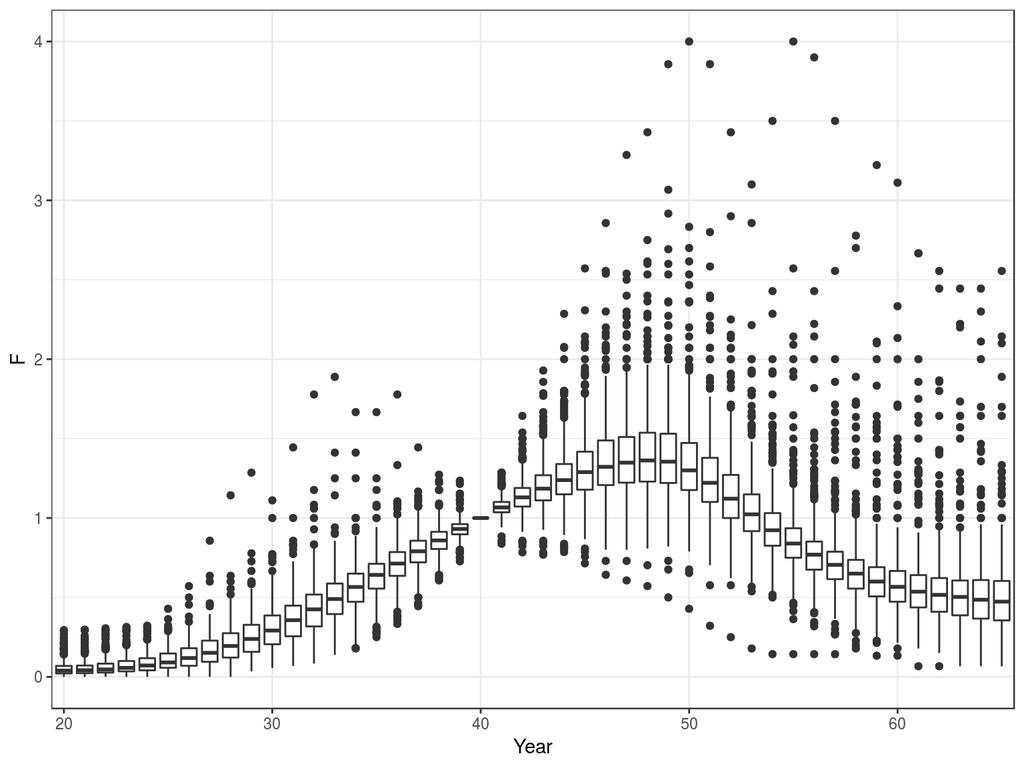

**Figure 24** Estimates of $F/M$ for razors.

## lobster

[figure not shown]

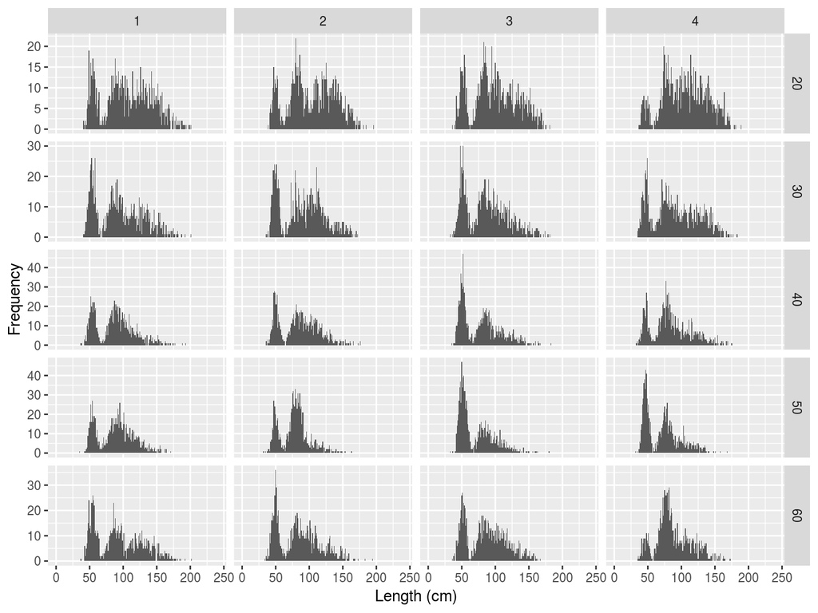

**Figure 26** Observation error model for lobster.

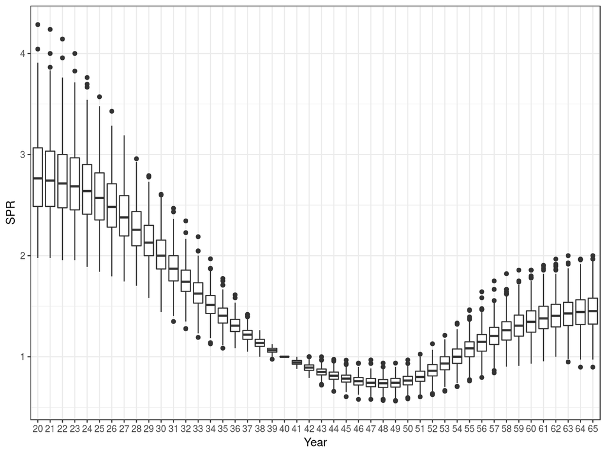

**Figure 27** Estimates of SPR for lobster.

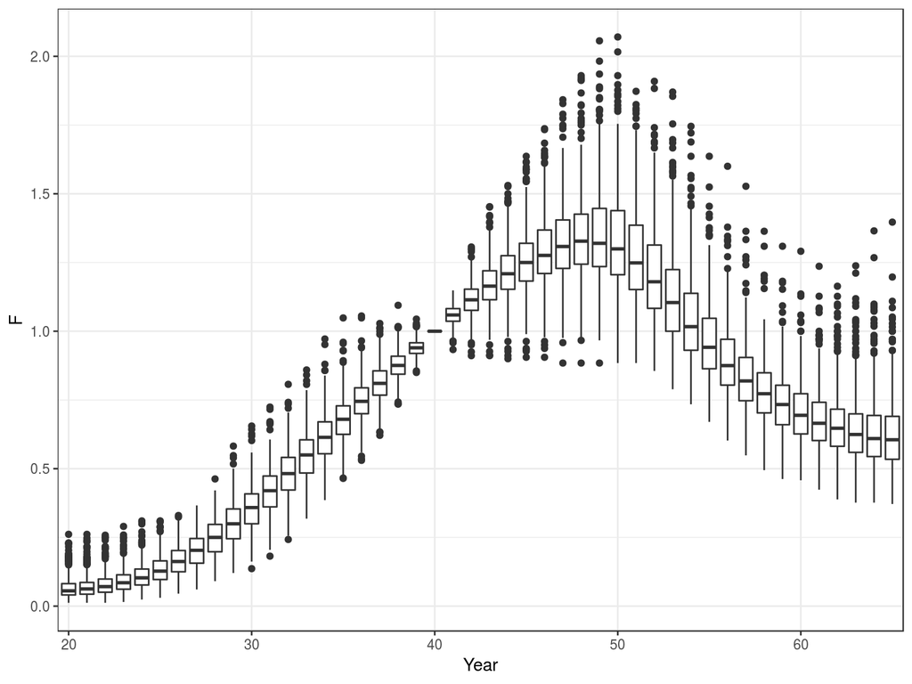

**Figure 28** Estimates of $F/M$ for lobster.

## Software Versions

- R version 3.4.4 (2018-03-15)
- FLCore: 2.6.9.9009
- FLife: 3.2.1.9001
- FLBRP: 2.5.3.9001
- **Compiled**: Sat Nov 17 17:08:16 2018

## Author information

**Laurence Kell**. laurie@seaplusplus.es

## Acknowledgements

This vignette and many of the methods documented in it were developed under the MyDas project funded by the Irish exchequer and EMFF 2014-2020. The overall aim of MyDas is to develop and test a range of assessment models and methods to establish Maximum Sustainable Yield (MSY) reference points (or proxy MSY reference points) across the spectrum of data-limited stocks.